# CUNY MSDS SPS DATA607 Week1

Keith Colella

2023-02-09

# Overview

This exercise explores the ‘primary-project-2022’ dataset from https://data.fivethirtyeight.com/. The data relates to four articles covering trends in the primary elections leading up to the 2022 mid-terms. Topics include the makeup of primary candidates, with a focus on race and gender.

I’ll aim to focus on one article: *People Of Color Make Up 41 Percent Of The U.S. But Only 28 Percent Of General-Election Candidates* (https://fivethirtyeight.com/features/2022-candidates-race-data/).

# Data Wrangling

```r
library(dplyr)
```

```r
library(ggplot2)
library(stringr)
```

## Reading in data

The original data set is split by party (Democrat / Republican). The data is stored on my github repository.

```r
dems <- read.csv('https://raw.githubusercontent.com/kac624/notebooks/main/CUNY/DATA607/dem_candidates.csv')
reps <- read.csv('https://raw.githubusercontent.com/kac624/notebooks/main/CUNY/DATA607/rep_candidates.csv')
```

## Cleaning Data

A subset of each dataframe is taken to choose only columns that are common to both. A column is added to retain a marker of party affiliation.

```r
dems_sub <- subset(dems, select = c(Candidate, Gender, Race.1, Race.2,
                                    Race.3, State, Office, District,
                                    Primary.., Primary.Outcome
                                    )
                   )

reps_sub <- subset(reps, select = c(Candidate, Gender, Race.1, Race.2,
                                    Race.3, State, Office, District,
                                    Primary.., Primary.Outcome
                                    )
                   )

dems_sub['Party'] = 'Democrat'
reps_sub['Party'] = 'Republican'
```

## Combining Data

The two data sets are combined and previewed.

```r
candidates <- rbind(dems_sub, reps_sub)
head(candidates,5)
```

```
##              Candidate Gender Race.1         Race.2 Race.3 State         Office
## 1           Gavin Dass   Male  White Asian (Indian)        Texas Representative
## 2       Victor D. Dunn   Male  Black                       Texas Representative
## 3 Jrmar "JJ" Jefferson   Male  Black                       Texas Representative
## 4        Stephen Kocen   Male  White                       Texas Representative
## 5        Robin Fulford Female  White                       Texas Representative
##   District Primary.. Primary.Outcome    Party
## 1        1       12%            Lost Democrat
## 2        1       28%     Made runoff Democrat
## 3        1       45%     Made runoff Democrat
## 4        1       15%            Lost Democrat
## 5        2      100%             Won Democrat
```

## Renaming Columns

Columns are renamed to use a consistent CamelCase convention, and unintuitive column names are clarified.

```r
candidates <- rename(candidates, c('Race1' = 'Race.1',
                                   'Race2' = 'Race.2',
                                   'Race3' = 'Race.3',
                                   'PercentOfVotes' = 'Primary..',
                                   'PrimaryOutcome' = 'Primary.Outcome'
                                   )
                     )
```

## Cleaning Levels in Race Columns

The labels for Race contain granular detail in many cases, which complicates any grouping that might be needed. A new Race column is created by removing these additional details. The field is then converted to a factor, with levels placed in reverse alphabetical order (to support alphabetical ordering in visualizations where coordinates are flipped, as done below).

```r
for (i in 1:nrow(candidates)) {
  if(grepl('\\(' , candidates$Race1[i])) {
    value <- substr(candidates$Race1[i],1,
                              str_locate(candidates$Race1[i],'\\(')[1,1]-2)
  } else{
    value <- candidates$Race1[i]
  }
  candidates$Race[i] <- str_trim(value)
}

candidates$Race <- as.factor(candidates$Race)

candidates$Race <- factor(candidates$Race,
                          levels=c('Unknown',
                                   'White',
                                   'Pacific Islander',
                                   'Native American',
                                   'Middle Eastern',
                                   'Latino',
                                   'Black',
                                   'Asian'))
```

# Visualization

A summary visualization is provided to show representation of various racial / ethnic groups in the slate of candidates running under each party. The visual is slightly skewed as there were more Republican candidates overall than Democrats (~1.5x). Still, candidates of color appear to be better represented among Democratic candidates as compared to Republican candidates, who were predominantly white.

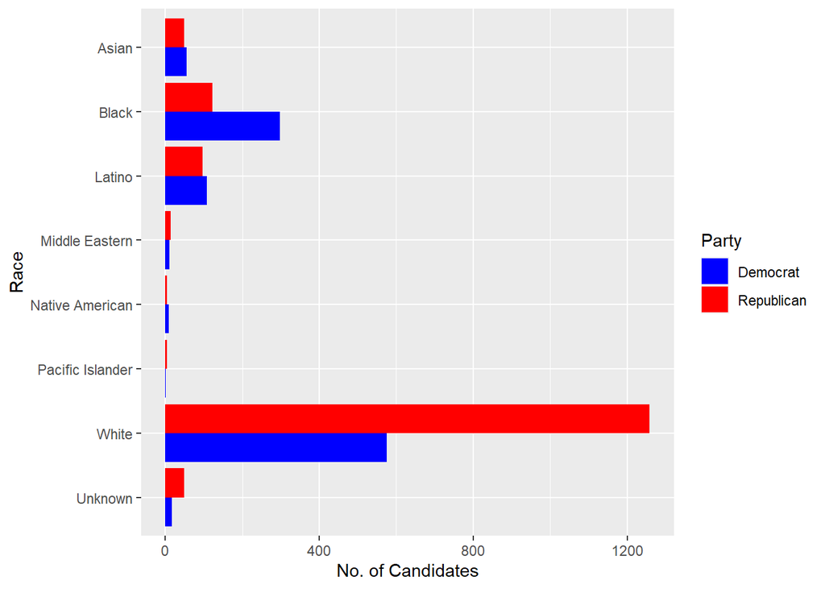

```r
candidates %>%
  group_by(Party, Race) %>%
  summarize(Count = n()) %>%
  ggplot(aes(x=Race, y=Count, fill=Party)) +
  geom_bar(stat='identity', position= 'dodge') +
  scale_fill_manual(values=c('blue','red')) +
  coord_flip() +
  labs(y  = 'No. of Candidates')
```

# Future Considerations

Future analysis of this data might focus on three things.

First, more nuanced treaetment of race / ethnicity could be applied. The visualization above considers only the primary racial identifier for each candidate, but many candidates identify with more than one racial group.

Second, I would like to consider the geographic element. Plotting winning candidates on a map of the US (based on the legislative district tagging) might prove an insightful visualization. Comparing the racial / ethnic representation of candidates to the racial composition of constituent communities would also prove insightful.

Finally, analysis might consider the intersection of key indicators (race, gender, geography, party) for winning an electoral contest.